# Exploratory analyses II

PCB 6455 / BSC 4933: Biometry | Lecture 6

Dr. Brian Maitner

## Today’s agenda

1. Discuss Assignment 1
2. Discuss potential data sources
3. Apply chapter 2 techniques to your own data
4. Work through 2.6

## The story so far

**Lecture 4:** reading real data into R, and checking that R read it right.

**Lecture 5:** looking at one or two variables at a time.

**Today:** many variables at once, groups side by side, and figures someone else can read.

## Research Opportunity

# Assignment 1

## Assignment 1

Full information online: see Canvas or GitHub.

**Overview:** select a dataset (you want one that can ask multiple questions), then do some exploratory analyses, and document them.

## Assignment 1

In this assignment, students will need to:

1. Select a dataset, provide a description, note where it came from
2. Read in their dataset
3. Note the class of the dataset itself (e.g., matrix, list, data frame, etc.)
4. List the variables of interest and their classes (e.g., numeric, character, etc.)
5. Examine the structure of the dataset and correct any formatting mistakes
6. Provide summary statistics for variables of interest
7. Produce at least 3 different figures that convey different information
8. For the figures in 7, briefly describe what the figures show

## You already have the tools

| Step | Where we did it |
| --- | --- |
| 1. Describe it, cite it | READMEs, Lecture 4 |
| 2. Read it in | Lecture 4: `read.csv`, `read_xlsx` |
| 3. Class of the dataset | Lecture 4: `class()` |
| 4. Variables and classes | Lecture 4: `str()` |
| 5. Fix formatting problems | Lecture 4: `-999`. Lecture 5: the kiwi |
| 6. Summary statistics | Lecture 4: `summary()`, `table()` |
| 7. Three figures | Lecture 5: `hist`, `plot`, `boxplot`, `barplot` |
| 8. Describe the figures | Lecture 5: what log-log changed |

We’re going to get more practice with some of these today as well.

## What counts as three different figures

“Three **different figures** that convey different information”

Three scatterplots of different variables is **one kind** of figure.

Different information means a different question, e.g.:

| Question | Plot |
| --- | --- |
| How is one variable distributed? | `hist` |
| How do two relate? | `plot` |
| How do groups compare? | `boxplot` |
| How many in each category? | `barplot` |

## Assignment 1: what you’ll submit

Needs to document what you did and be reproducible. Either:

| Submit | See this folder for an example |
| --- | --- |
| The output of an `.Rmd` file showing code and outputs (e.g., html, pdf) | `example_R_markdown/` |
| A `.R` file that can be run anywhere | `example_R_commented/`, for comment examples |

## How and when

Assignments can be submitted on Canvas. You can either:

**Upload your file to GitHub** and submit the link on Canvas (required for grads, extra credit for undergrads), or

**Upload the file on Canvas.**

**Due Friday, Sept. 18th before midnight.**

## “Runs anywhere” includes the data

```r
# Only works on my laptop
read.csv("C:/Users/bmaitner/Desktop/.../AVONET1_BirdLife.csv")

# Works if you have the course repo open
read.csv("data/Avonet/AVONET1_BirdLife.csv")

# Works for anyone, anywhere
read.csv("https://github.com/bmaitner/biometry_course/raw/refs/heads/main/data/Avonet/AVONET1_BirdLife.csv")
```

**Using your own data? Put it in your repo and link it, or link the original source.**

## Documenting what you did

**Open** `example_R_commented/Example.R`

**Comments say why, not what:**

```r
x <- log10(mass)   # take the log of mass (not great)
x <- log10(mass)   # mass spans 5 orders of magnitude (better)
```

| Shortcut | What it does |
| --- | --- |
| Ctrl (Cmd) + Shift + R | makes a section |
| Ctrl (Cmd) + Shift + C | makes a comment (or comments out highlighted code) |
| Ctrl (Cmd) + Shift + O | opens an outline |

**Try these commands out.**

## Questions so far?

# Finding data

## Getting data

|  | Pro | Con |
| --- | --- | --- |
| **Collect it** | you know it best, can be tailored to a specific question | time-consuming, possibly expensive, probably requires cleaning |
| **Download it** | quick | less knowledge of collection, probably still needs cleaning |
| **Aggregate it** | data volume and breadth | even less knowledge of collection, lots of standardization and cleaning required |

## Where to look for data

| Where | What you’ll find |
| --- | --- |
| **Course GitHub site** | links to resources; the `data/` folder contains some options |
| **Scientific publications** | supplementary information; data publications (e.g., [Scientific Data](https://www.nature.com/sdata/)) |
| **Data repositories** | [Dryad](https://datadryad.org/), [TRY](https://www.try-db.org/TryWeb/Home.php) |

## Datasets of interest to this class

Mangrove invert communities

Marine microorganisms

Deep sea megabenthos

Bird survey data

Coral populations

**Reef fish data**

[figure not shown]

## Datasets of interest to this class

General places to look for data are noted on the course GitHub homepage.

The data folders on the course GitHub each have a **README file** with useful information.

You may need to look up the data sources to understand all the column names.

# Now do it to your own data

## Now do it to your own data

**Open a new script. Read your dataset in.**

```r
avonet <- read.csv("https://github.com/bmaitner/biometry_course/raw/refs/heads/main/data/Avonet/AVONET1_BirdLife.csv")
```

I’ll show each step on the bird data. Then you do it on yours.

By the end you’ll have three figures, labeled and saved. That’s Assignment 1, steps 6 to 8.

**No dataset yet?** Use AVONET for now, and modify your code later.

## Assessing many variables at once

Note: if using a different dataset, use your variables.

```r
beak <- avonet[c("Beak.Length_Culmen",
                 "Beak.Length_Nares",
                 "Beak.Width",
                 "Beak.Depth")]
round(cor(beak), 2)
```

**What do these lines of code do?**

```
                   Culmen Nares Width Depth
Beak.Length_Culmen   1.00  0.97  0.74  0.71
Beak.Length_Nares    0.97  1.00  0.73  0.70
Beak.Width           0.74  0.73  1.00  0.91
Beak.Depth           0.71  0.70  0.91  1.00
```

## The same thing as a picture

```r
pairs(x = beak,
      pch = 16,
      cex = 0.3,
      col = rgb(red = 0,
                green = 0,
                blue = 0,
                alpha = 0.15)
      )
```

Same code, different style:

```r
pairs(beak,pch=16,cex=0.3,col=rgb(0,0,0,0.15))
```

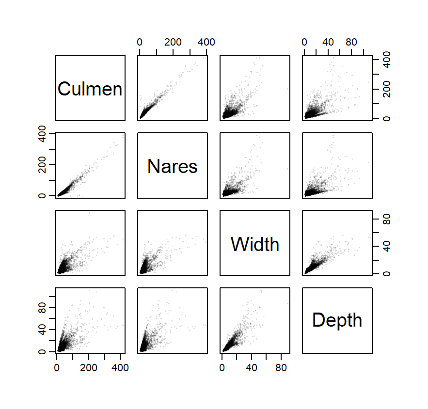

**Your turn:** try this on your data.

## Correlations in your own data

Did anyone find any suspiciously high correlations?

Or anything that might need log-scaling?

## Comparing groups

```r
pelicans <- avonet[which(
  avonet$Order1 == "Pelecaniformes"), ]
nrow(pelicans)
boxplot(log10(Mass) ~ Family1,
        data = pelicans)
```

**Check:** 110 species, in 5 families

Note the use of `which()` to select only Pelecaniformes!

**Your turn:** try a boxplot on your data (figure 1 of 3!)

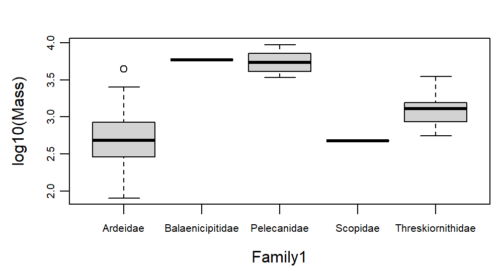

## Two plots side by side

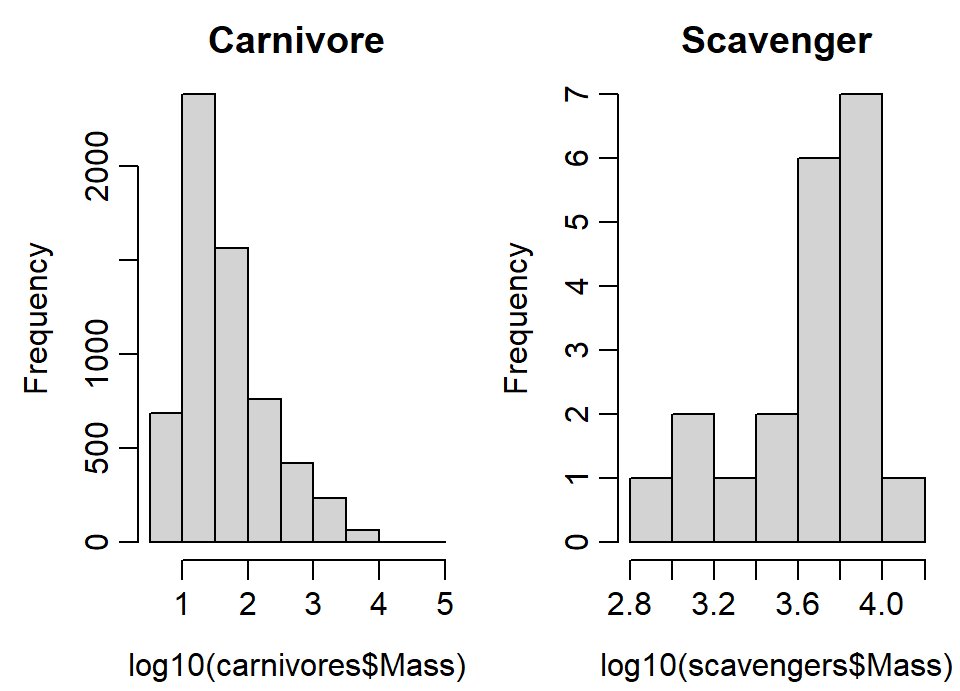

```r
carnivores <- avonet[which(
 avonet$Trophic.Level == "Carnivore"), ]
scavengers <- avonet[which(
 avonet$Trophic.Level == "Scavenger"), ]
par(mfrow = c(1, 2))
 hist(log10(carnivores$Mass),
      main = "Carnivore")
 hist(log10(scavengers$Mass),
      main = "Scavenger")
par(mfrow = c(1, 1))   # put it back!
```

## Look before you believe it

Scavengers look about as common as carnivores.

**Read the y axes.**

We can sanity check with:

```r
nrow(carnivores)
nrow(scavengers)
```

**Check:** 6,115 and 20

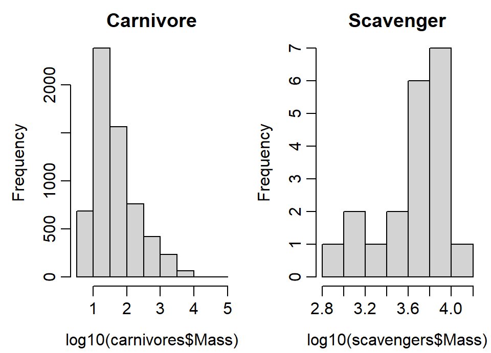

## Two plots side by side

```r
carnivores <- avonet[which(
 avonet$Trophic.Level == "Carnivore"), ]
scavengers <- avonet[which(
 avonet$Trophic.Level == "Scavenger"), ]
par(mfrow = c(1, 2))
 hist(log10(carnivores$Mass),
      main = "Carnivore")
 hist(log10(scavengers$Mass),
      main = "Scavenger")
par(mfrow = c(1, 1))   # put it back!
```

**Your turn:** plot two groups from your data side by side.

Potential figure 2 of 3.

## Four groups, four blocks

What about all four groups?

```r
herbivores <- avonet[which(
avonet$Trophic.Level == "Herbivore"), ]
omnivores <- avonet[which(
avonet$Trophic.Level == "Omnivore"), ]
```

…then four `hist()` calls, differing by one word each, with `ylim` written out four times.

**What’s the issue with this approach?**

## For loops

A `for()` loop does it once.

```r
for (level in c("Carnivore", "Herbivore",
                "Omnivore", "Scavenger")) {
  print(level)
}
```

Runs the code in `{ }` once per element, setting `level` to each in turn.

Now we put the plotting code inside!

## For loops

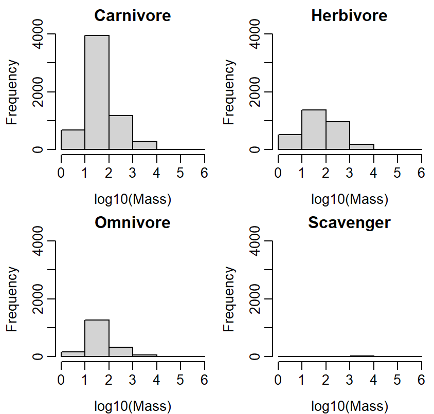

```r
par(mfrow = c(2, 2))
for (level in c("Carnivore", "Herbivore",
                "Omnivore", "Scavenger")) {
  print(level)
  group_data <- avonet[which(
    avonet$Trophic.Level == level), ]
  hist(log10(group_data$Mass),
       main = level,
       xlab = "log10(Mass)",
       ylim = c(0, 4000), breaks = c(0:6))
}
par(mfrow = c(1, 1))
```

## Making figures readable

```r
plot(x = log10(avonet$Mass),
     y = log10(avonet$Wing.Length))
```

Not bad, but could be improved.

**How can we see the available arguments for `plot()`?**

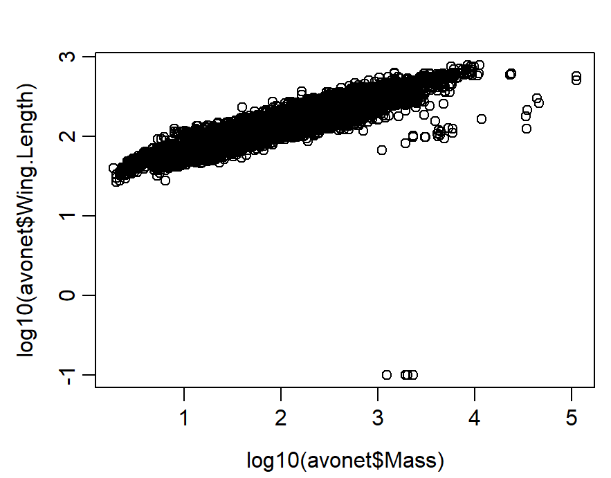

## Making figures readable

```r
plot(x = log10(avonet$Mass),
     y = log10(avonet$Wing.Length),
     xlab = "Body mass (log10 g)",
     ylab = "Wing length (log10 mm)",
     main = "Wing length scales with body mass")
fit <- lm(log10(Wing.Length) ~ log10(Mass),
          data = avonet)
abline(fit, col = "red", lwd = 3)
```

**Your turn:** make a scatterplot from your own data (potential figure 3 of 3).

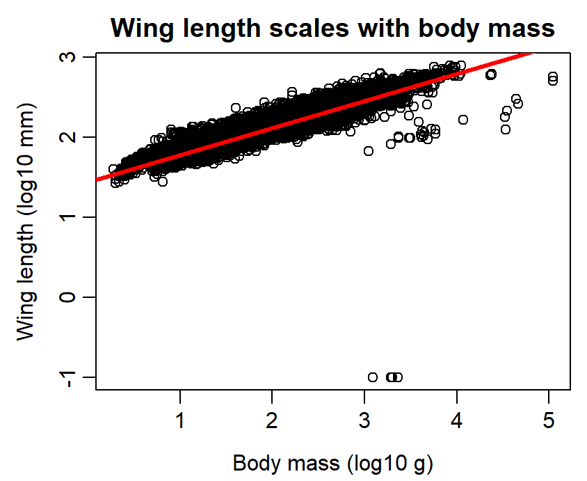

## Saving a figure

```r
png("my_figure.png",
    width = 900, height = 650)
plot(log10(avonet$Mass),
     log10(avonet$Wing.Length))
dev.off()   # nothing is written until this
```

Nothing appears in the Plots pane. That’s normal.

**Your turn:** save all three figures. Write a commented-out sentence below the code describing what each plot shows.

# Wrapping up

## Which tool, when

| You want to | Use |
| --- | --- |
| see how many variables relate, as numbers | `cor()`, with `use = "complete.obs"` if there are NAs |
| see how many variables relate, as a picture | `pairs()` |
| pull out one group | `data[which(data$column == "value"), ]` |
| compare a number across groups | `boxplot(y ~ group, data = )` |
| put plots side by side | `par(mfrow = c(rows, columns))`, then put it back |
| compare panels fairly | the same `ylim` in each, and n in the title |
| do the same thing for each group | `for (x in values) { ... }` |
| make a figure readable | `xlab`, `ylab`, `main`, with units |
| save a figure | `png()`, plot, `dev.off()` |

## Remainder of class

Continue working on 2.6.

Start working on Assignment 1.

## Before next class

Read and work through **R for Data Science, chapter 3**: r4ds.hadley.nz/data-transform.html